# Snow Depth Analyses

AnnaClaire Marley

7/5/2019

### Daily Snow Depth Variability for Each Region (November - April Water Year)

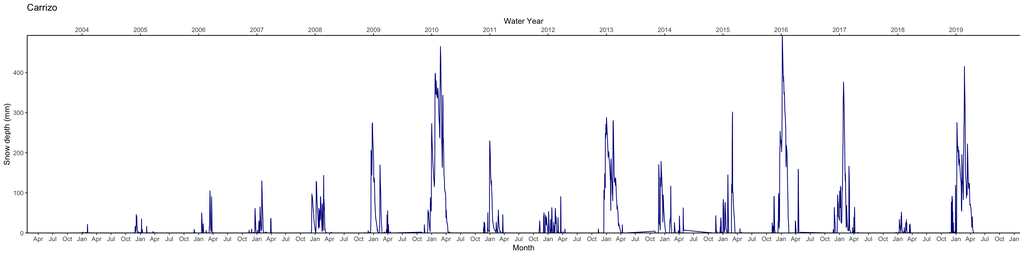

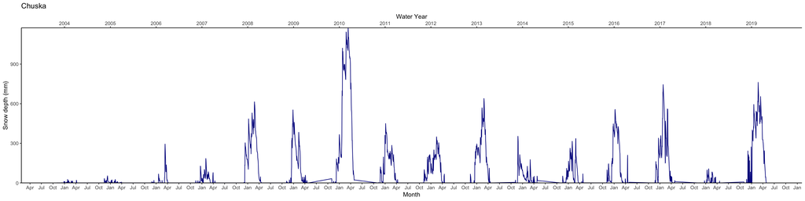

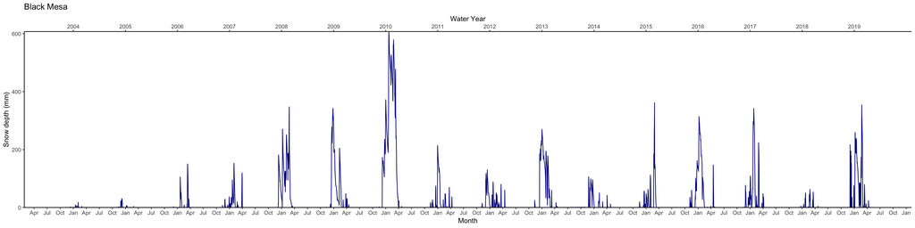

## Monthly Mean Snow Depth variability (November - April Water Year)

Carrizo:

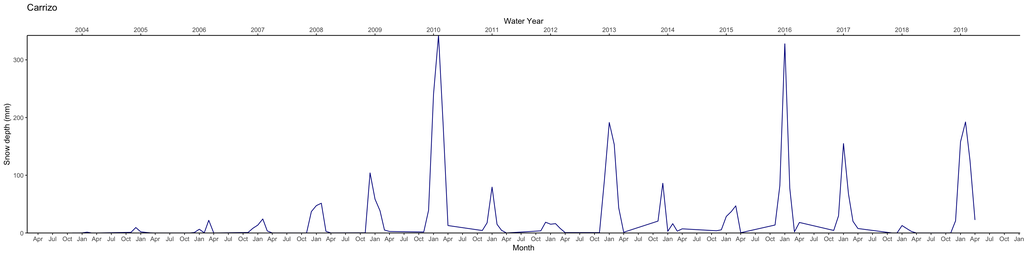

Chuska:

- low years: 2004-2007, 2014, 2018

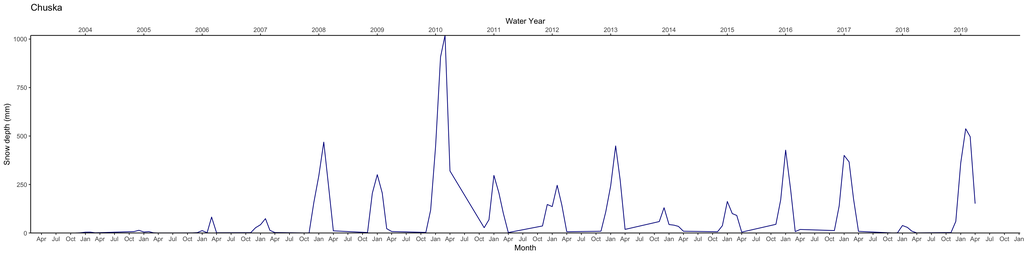

Black Mesa:

- low years: 2004-2007, 2011-2012, 2014-2015, 2018

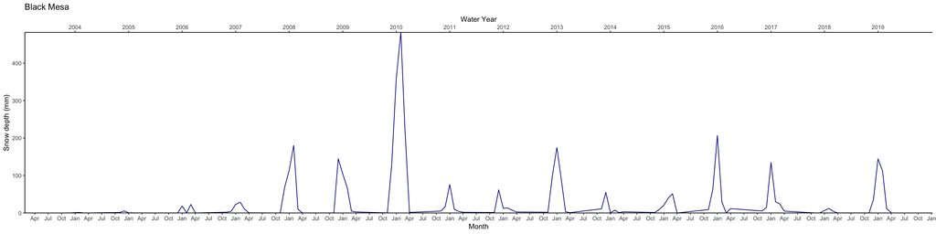

### Correlation of monthly mean snow depths

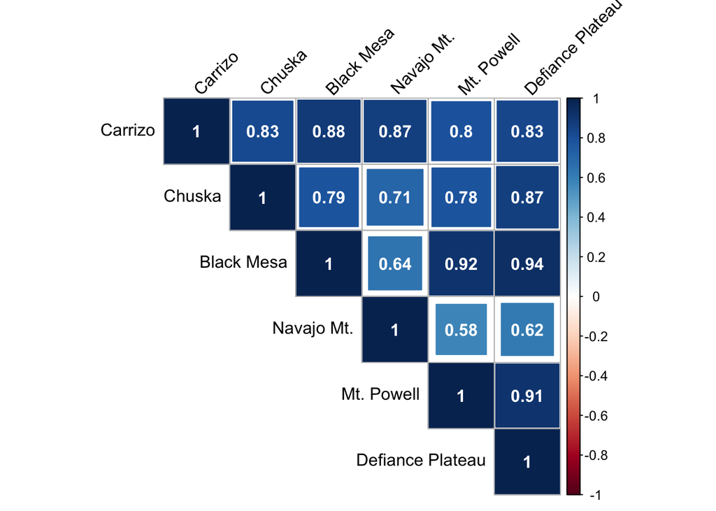

- Least correlated are mt powell and navajo mt. This makes sense as they are the furthest sites from each other
- Next is defiance plateau and navajo mt which are the next farthest from each other
- This trend does not continue, because navajo mt and black mesa are the next least correlated. However, Black Mesa is the cosest mountain range to navajo mt. but black mesa appears to be much lower elevation than navajo mt, which may explain
- The higest correlation is between black mesa and defiance plateau. They are relatively close and appear to have similar elevations

## Anomalies

Difference from the monthly mean for each region

Carrizo:

- Anomalously dry years: 2004-2008, 2011-2012, 2018
- most of 2009, 2014 and 2015 also mostly negatively anomalous

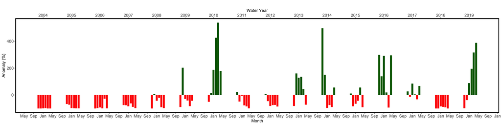

Chuska:

- Anomalously dry years: 2004-2007, 2015, 2018

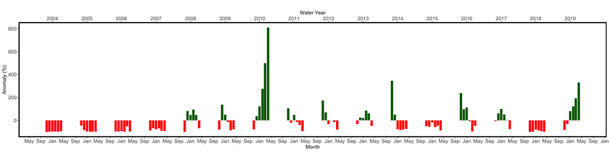

Black Mesa:

- Anomalously dry years: 2004-2007, 2011, 2012, 2014, 2015, 2018

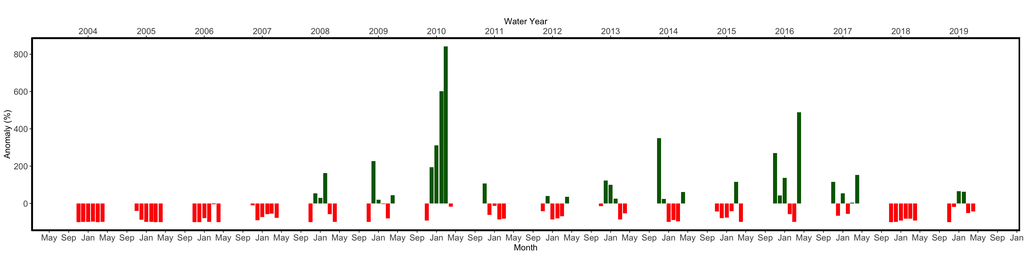

### Weekly Mean Correlations between sites

Pearson’s R Squared values:

*Black Mesa and Carrizo most closely correlated even though Carrizo and the Chuskas are closer and have more similar elevations. Black Mesa and Chuska least closely correlated*

- Carrizo vs Chuska: 0.66
- Carrizo vs Black Mesa: 0.79
- Black Mesa vs Chuska: 0.58

### Average snowdepth values for each months at each site

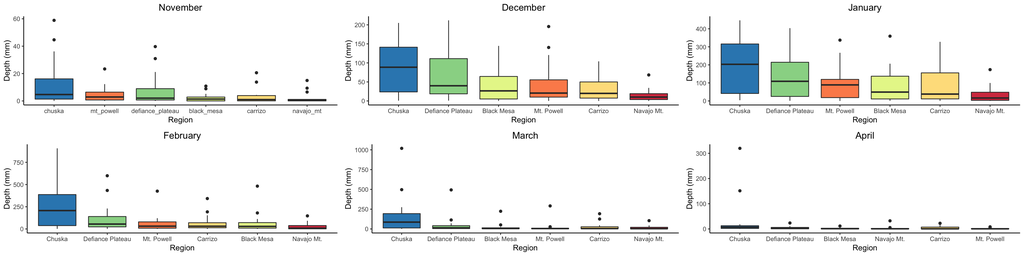

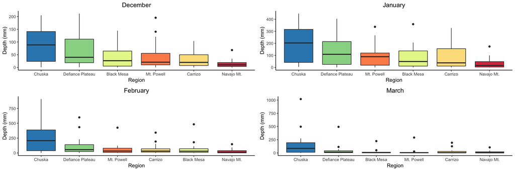